# PrediccionApple

Gonzalo Carretero Ursúa

11/16/2020

# LibreríasI

```r
library(readr)
library(forecast)
library(xts)
```

```r
library(ggplot2)
library(ggfortify)
```

# Datos

```r
rawData <- read.csv('IngresosApple.csv', sep = ';')
rawVentas<-rawData$Ingresos
rawDate <- seq(as.Date('2008/04/01'), as.Date('2017/07/01'), by = 'quarter')

xVentas=xts(rawVentas,order.by=rawDate)
# Transformación del data se
xVentas=to.quarterly(xVentas)
zVentas = as.zoo(xVentas$xVentas.Close)
names(zVentas)="Primas"
View(zVentas)
```

# Visualización gráfica

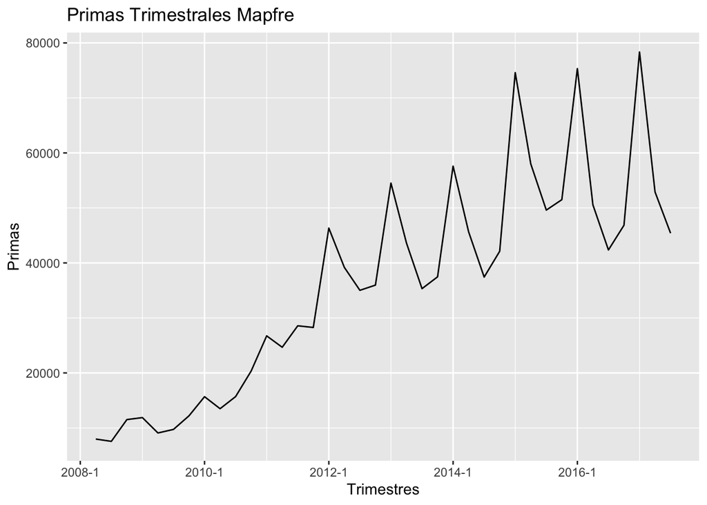

```r
autoplot(zVentas)+ggtitle("Primas Trimestrales Mapfre")+xlab("Trimestres")+ylab("Primas")
```

En el gráfico podemos observar que la serie no es estacionaria ni en media ni en varianza. No es estacionaria en media por que se aprecia una tendencia positiva clara, y, no es estacionaria en varianza por la variabilidad que presenta a lo largo de la serie.

# Representación por trimestres

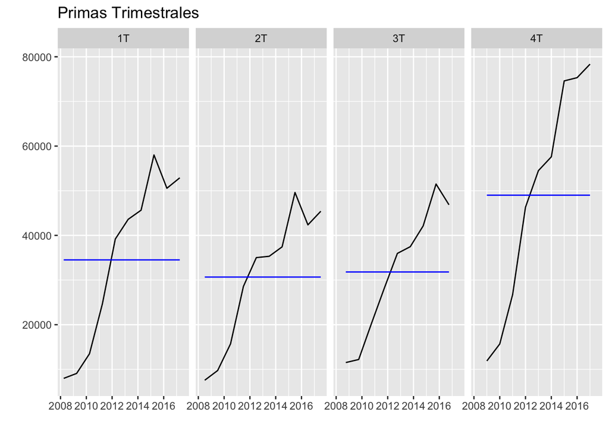

```r
tsVentas=ts(coredata(zVentas), start = c(2008, 2), frequency = 4)
#Seasonal Plot
ggfreqplot(tsVentas,freq=4,nrow=1,facet.labeller=c("1T","2T","3T","4T"))+ggtitle("Primas Trimestrales")
```

Si observamos por trimestres se muestra cómo el cuarto trimestre presenta una media bastante superior a la media de los otros tres trimestres del año. Con esto se concluye que el cuarto trimestre es en el que Apple consigue el mayor ingreso por ventas.

# Predicción con el modelo ETS

Se utiliza el modelo ETS para predecir. La columna de la salida ‘Point Forecast’ es el valor que nos predice R con el modelo empleado.

```r
cOmit=4
nObs=length(zVentas)
oVentas <- window(zVentas,start=index(zVentas[1]),end=index(zVentas[nObs-cOmit]))
etsfit<-ets(oVentas)
fventas.ets=forecast(etsfit)
summary(fventas.ets)
```

```
##
## Forecast method: ETS(M,A,M)
##
## Model Information:
## ETS(M,A,M)
##
## Call:
##  ets(y = oVentas)
##
##   Smoothing parameters:
##     alpha = 0.4652
##     beta  = 0.4652
##     gamma = 0.5311
##
##   Initial states:
##     l = 7122.371
##     b = 1492.6432
##     s = 1.1496 1.1214 0.8327 0.8962
##
##   sigma:  0.1175
##
##      AIC     AICc      BIC
## 679.8611 687.3611 693.5983
##
## Error measures:
##                     ME    RMSE     MAE        MPE     MAPE      MASE      ACF1
## Training set -322.6123 4042.51 2733.75 -0.8774628 8.428508 0.3901659 0.1319957
##
## Forecasts:
##         Point Forecast       Lo 80    Hi 80      Lo 95     Hi 95
## 2016 Q4       38518.08  32716.5807 44319.59  29645.450  47390.72
## 2017 Q1       56113.05  44132.4513 68093.64  37790.308  74435.78
## 2017 Q2       38594.10  26026.2941 51161.90  19373.301  57814.89
## 2017 Q3       31722.60  16354.0087 47091.19   8218.367  55226.84
## 2017 Q4       28760.23   7397.6189 50122.85  -3911.066  61431.53
## 2018 Q1       40797.81    184.7347 81410.88 -21314.526 102910.14
## 2018 Q2       27185.53  -9001.0390 63372.10 -28157.051  82528.11
## 2018 Q3       21504.22 -16699.6423 59708.07 -36923.543  79931.98
```

# Representación gráfica con la predicción

Representación gráfica de la predicción con modelo ETS.

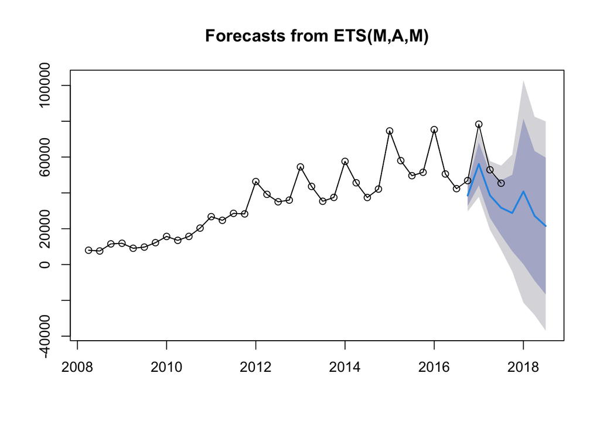

```r
plot(fventas.ets)
lines(window(zVentas),type="o")
```

# Predicción con modelo ARIMA

Se aplica logaritmo para evitar la variabilidad en varianza

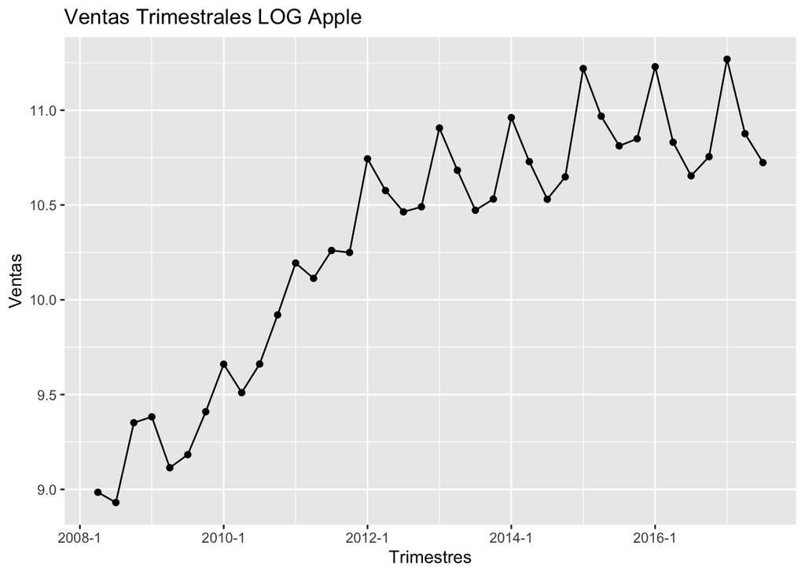

```r
zlVentas=log(zVentas)
df_newl <- data.frame(value = as.vector(zlVentas),
                     time = time(zlVentas))
ggplot(df_newl)+geom_point(aes(x=time,y=value))+geom_line(aes(x=time,y=value))+ylab("Ventas")+ggtitle("Ventas Trimestrales LOG Apple")+xlab("Trimestres")
```

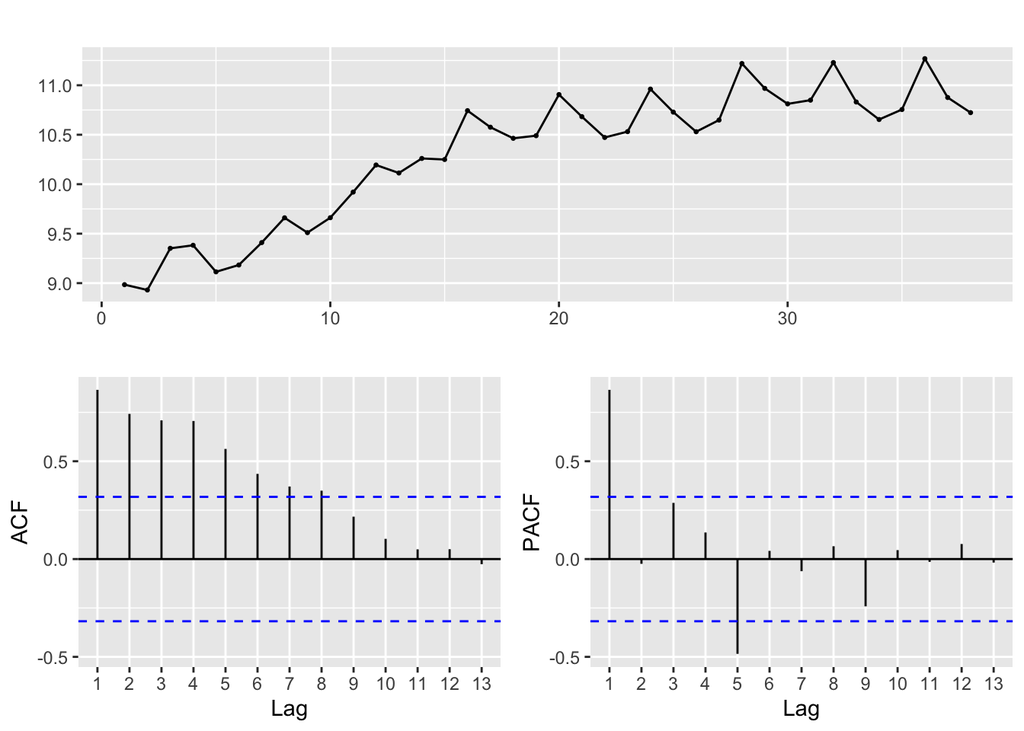

```r
ggtsdisplay(zlVentas)
```

# Diferencias para evitar la tendencia

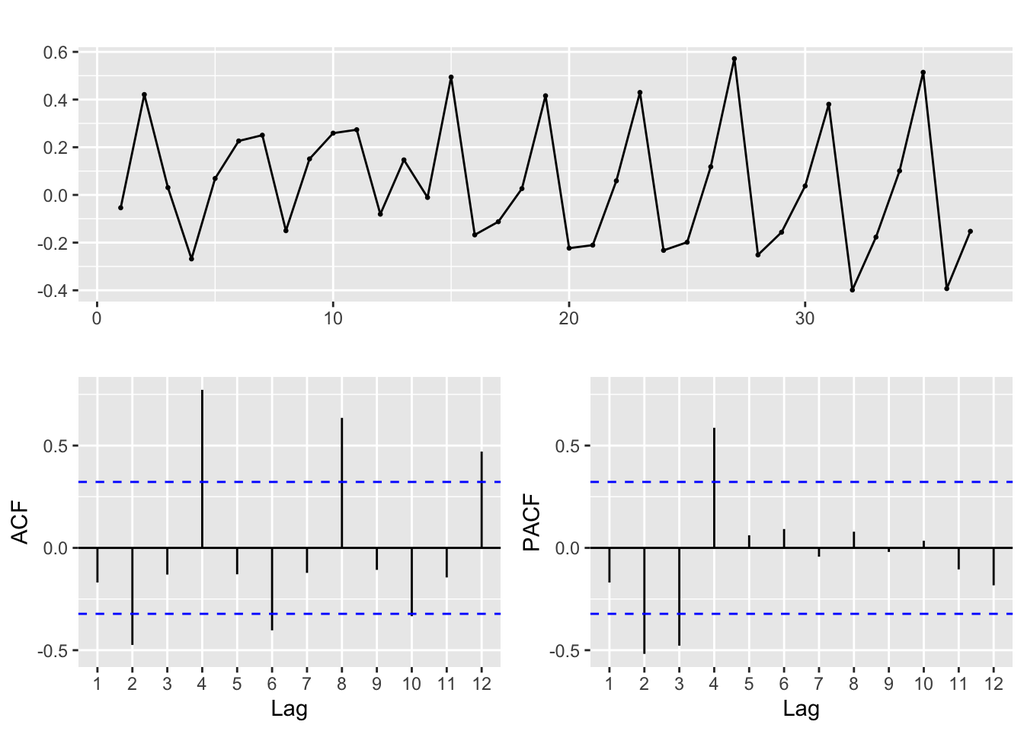

```r
ggtsdisplay(diff(zlVentas))
```

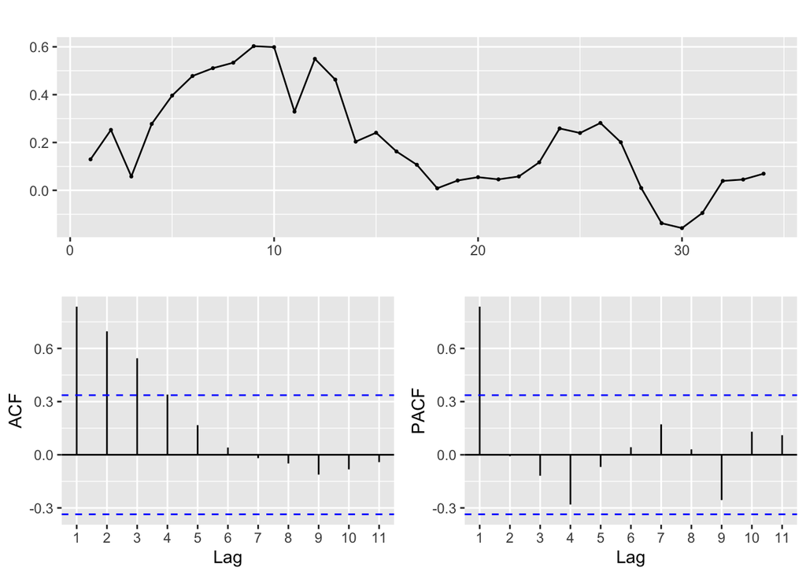

```r
ggtsdisplay(diff(zlVentas,4))
```

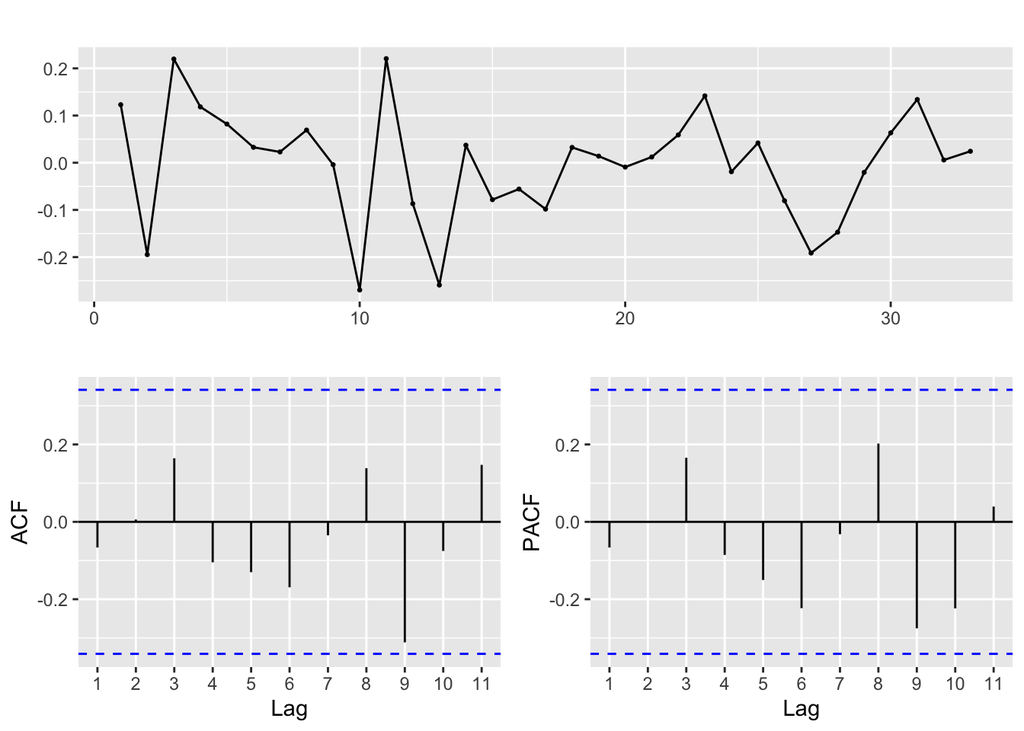

```r
ggtsdisplay(diff(diff(zlVentas,4),1))
```

```r
fit1=auto.arima(oVentas,lambda=0)
summary(fit1)
```

```
## Series: oVentas
## ARIMA(0,1,0)(0,1,0)[4]
## Box Cox transformation: lambda= 0
##
## sigma^2 estimated as 0.01509:  log likelihood=19.67
## AIC=-37.35   AICc=-37.2   BIC=-35.98
##
## Training set error measures:
##                     ME     RMSE     MAE       MPE     MAPE     MASE      ACF1
## Training set -871.5499 4831.189 3059.32 -1.540967 8.348157 0.436632 0.1290665
```

# Análisis de residuos

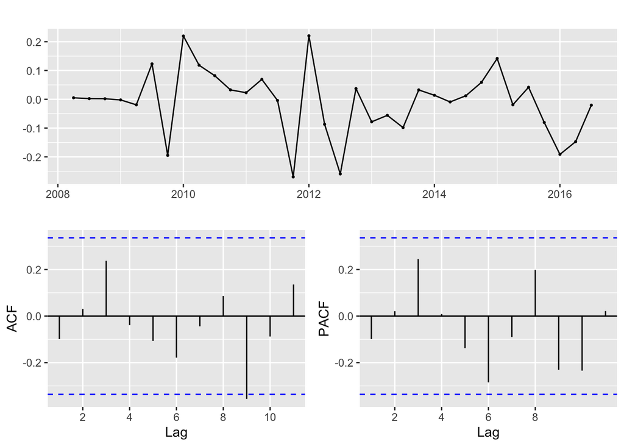

```r
ggtsdisplay(fit1$residuals)
```

```r
Box.test(fit1$residuals,lag=4, fitdf=3, type="Lj")
```

```
##
##  Box-Ljung test
##
## data:  fit1$residuals
## X-squared = 2.6855, df = 1, p-value = 0.1013
```

```r
Box.test(fit1$residuals,lag=12, fitdf=3, type="Lj")
```

```
##
##  Box-Ljung test
##
## data:  fit1$residuals
## X-squared = 13.21, df = 9, p-value = 0.1533
```

# Predicción con modelo ARIMA

```r
fventas.arima=forecast(fit1)
df_new <- data.frame(value = as.vector(zVentas),
                     time = time(zVentas))
fventas.arima=forecast(fit1)
fventas.arima
```

```
##         Point Forecast    Lo 80    Hi 80    Lo 95     Hi 95
## 2016 Q4       43977.01 37571.16 51475.04 34566.95  55948.72
## 2017 Q1       64319.60 51481.60 80359.03 45757.97  90410.72
## 2017 Q2       43170.92 32867.68 56703.97 28449.86  65509.21
## 2017 Q3       36169.74 26399.96 49555.01 22346.85  58542.94
## 2017 Q4       37552.22 24057.64 58616.28 19005.64  74197.42
## 2018 Q1       54922.89 31835.30 94754.03 23852.35 126466.51
## 2018 Q2       36863.90 19638.89 69196.73 14071.59  96573.82
## 2018 Q3       30885.56 15275.33 62448.24 10522.73  90653.01
```

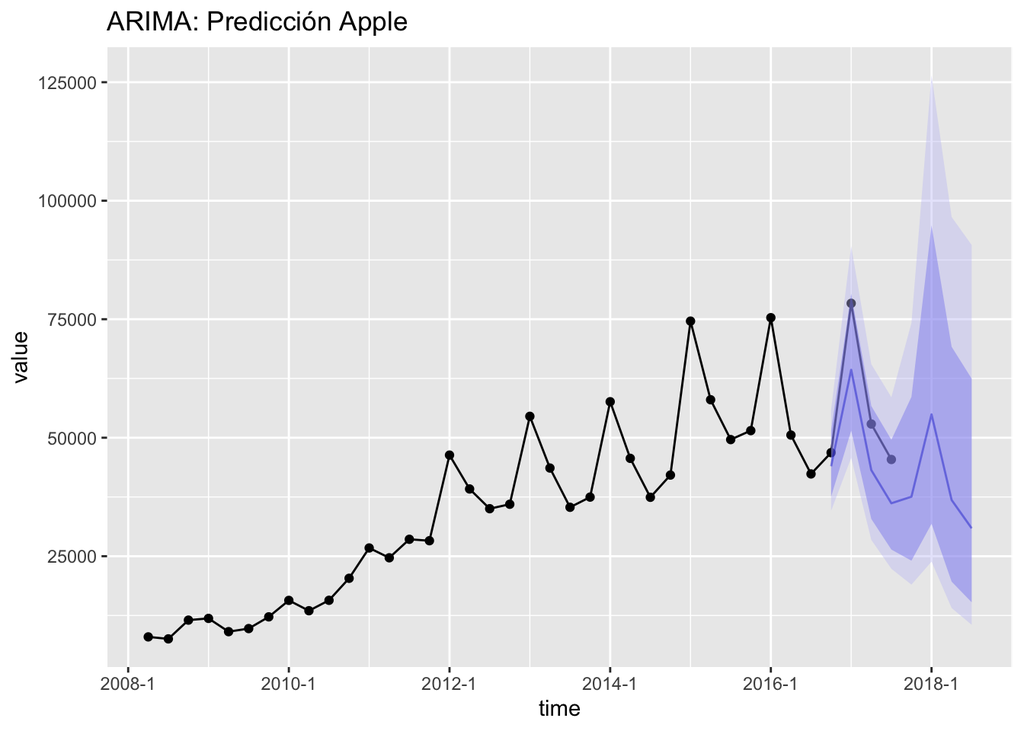

```r
ggplot(df_new)+geom_point(aes(x=time,y=value))+geom_line(aes(x=time,y=value))+ geom_forecast(fventas.arima,alpha=0.4)+ggtitle("ARIMA: Predicción Apple")
```